# Introduktion till praktikkursen, 30hp

KOMB27: Yrkespraktik i strategisk kommunikation HT25

stratkom@iko.lu.se,  
nils.holmberg@iko.lu.se

## Varför praktik?

- Inblick i olika yrkesroller
- Utveckla kompetenser
- Förbereda för yrkeslivet
- Skapa kontaktyta med möjliga arbetsgivare
- Kunskaper kommer till nytta i studierna
- MEN OCKSÅ: Lär dig vad du tycker om (eller inte…)

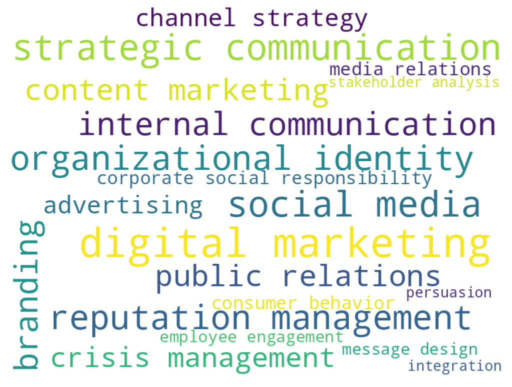

## Tänk på!

- inte enbart operativa arbetsuppgifter – det är viktigt med ett strategiskt perspektiv också
- börja i god tid med litteratur och uppgifter
- det är en akademisk kurs – inte arbete (du ska inte ersätta en anställd på arbetsplatsen)
- ta upp eventuella problem på praktikplatsen i tid
- hör av er till mig vid frågor och funderingar – jag finns tillgänglig på office hours via zoom!

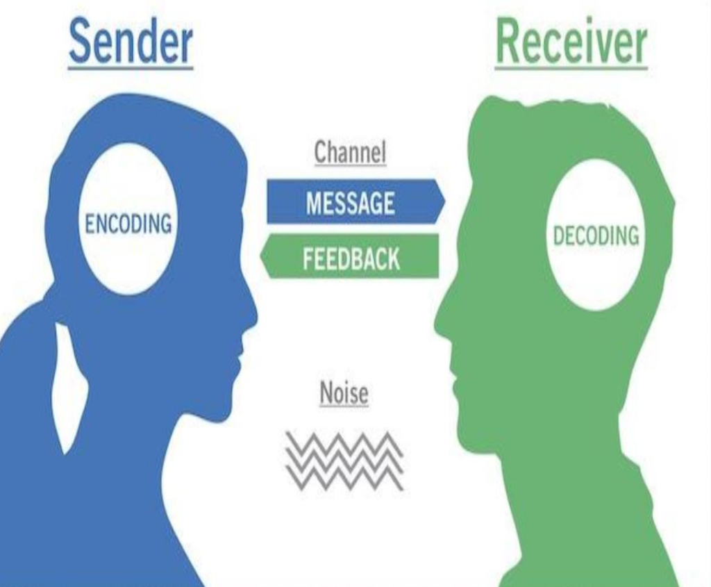

## Praktikens omfattning

- Kursen omfattar 30 hp
- Period 1 – 4: 2025-09-01 till 2026-01-18
- Ca 19 – 20 veckors kurstid (beroende på terminsgränser)
- Ska omfatta minst 720 timmars arbete = 90 dagars heltidsarbete
- Studenten är försäkrad från universitetet under praktikperioden (men inte före och efter)

```
Total days in the period: 140
Number of full weeks:     20
Number of Swedish workdays (Mon-Fri excluding holidays): 94

90 workdays * 8 hours per day full time: 720 hours internship
```

## Praktik och studier (1/2)

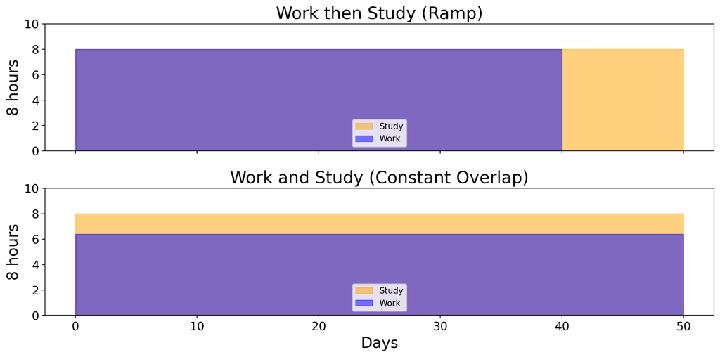

## Praktik och studier (2/2)

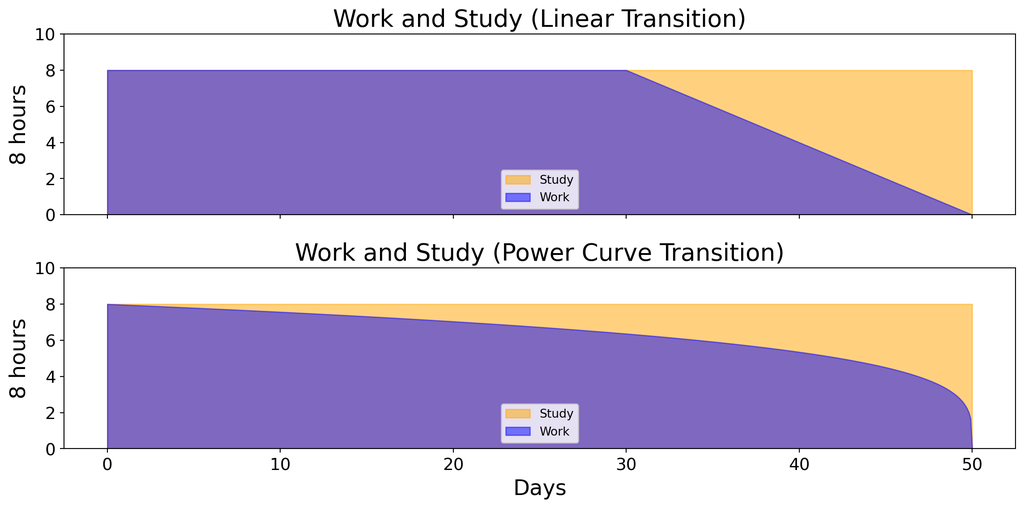

## 1. Före kursstart

- Hitta en praktikplats!
- Skriv och lämna in praktikplan på canvas
- Skriv trepartsavtal med din praktikplats
- Kolla deadlines i canvas!
- Maila avtal som pdf till kursansvarig för underskrift
- Din registrering på kursen

## 2. Under kursen

- Drop-in via zoom – boka tid med kursansvarig.
- Handledning på praktikplatsen.
- Skriv på praktikrapport. Tänk på att avsätta tid för rapporten och kom gärna överens med praktikplatsen om en plan för det!
- Praktiken ska vara minst 18 av 20 veckor = det finns ca 2 veckor till godo för skrivande av rapport och eventuell oväntad frånvaro, t.ex. sjukdom.

## Handledning

#### 2. Under kursen

- Nödvändigt att ha en handledare på arbetsplatsen.
- Minst tre tillfällen:
  1. Början: introduktion, praktiska frågor, avstämning av praktikplan
  2. Mitten: Hur fungerar praktiken; feedback på dina arbetsinsatser; planering av fortsatt arbete, tillstånd att använda arbetsprover (pga. sekretess etc.)
  3. Avslutning: Återkoppling och uppföljning av praktiken i sin helhet; frågor om framtiden (referens?)

## Praktikrapport

#### 2. Under kursen

- Fem delar (följ instruktioner på canvas):
  1. Arbetsplatsen och din avdelning
  2. Dina arbetsuppgifter
  3. Värdet av praktiken
  4. Din framtida yrkesbana
  5. Råd till framtida praktikanter
- Cirka 3000 ord (exkl. titelsida, innehållsförteckning och bilagor) med portfölj som bilaga

## Portfölj

#### 2. Under kursen

- Egen inlämning, Praktikrapport Del 2: Dina arbetsuppgifter.
- Bifoga minst tre representativa exempel på arbetsuppgifter du har utfört.

| Exempelvis: |
| --- |
| Texter av olika slag (pressreleaser, redaktionellt material, webbtexter etc.) |
| Beskrivningar av evenemang du har medverkat till att planera och genomföra |
| En undersökning du har genomfört |
| En kommunikationsplan |

## Kurslitteratur

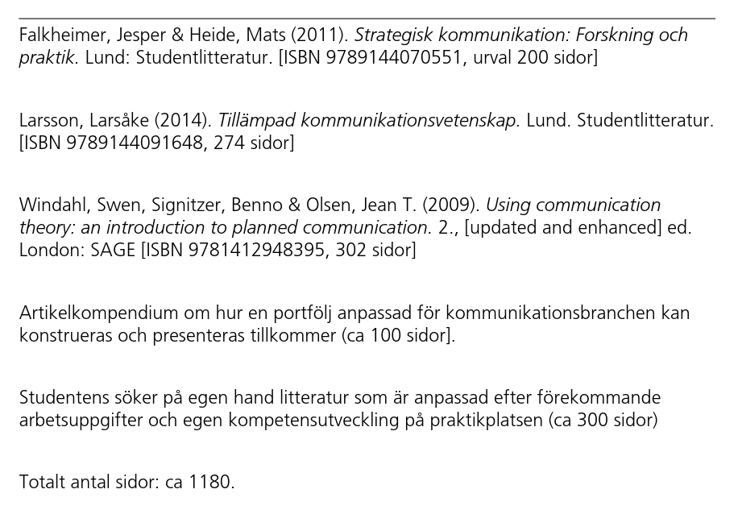

## 3. Kursavslutning

- Inlämning av praktikrapport ca en vecka innan seminarium
- Slutseminarium för erfarenhetsutbyte (anordnas via zoom)
- Inlämning av praktikintyg i slutet av terminen
- Examinationer i canvas och slutbetyg i LADOK
- Kolla deadlines i canvas!

## Praktikintyg

#### 3. Kursavslutning

- Inlämning av praktikintyg i slutet av terminen:
  1. Laddas ner från canvas
  2. Fyll i studentens personuppgifter
  3. Intyg på 720 timmars praktik
  4. Skrivs under av praktikhandledare

[figure not shown]

## Examination, 6 delar

1. **praktikplan**
2. **trepartsvatal**
3. **reflektionspapper (15 hp)**
4. **portfölj (15 hp)**
5. **slutseminarium**
6. **praktikintyg (0 hp)**
- Betyg: G / U